# index

# Introduction

The incarceration trends dataset by **Vera** is an important one that answers questions regarding the rehabilitation and process of recovery of the U.S.’s inmates as well as questions regarding the justice system. Particularly with this assignment, I want to focus on the prison population of inmates from different races and compare them to see how they differ. The variables I’d like to focus on includes all the prison population by race columns, particularly the black, white, and aapi communities, the location such as state or urban/rural areas, and the difference between genders.

# Summary Information

The first relevant value of interest I’d like to calculate is the state with the largest number of prisoners. Turns out, this value is Florida with 54835 prisoners. This would allow me to better understand where these inmates are and to help compare this value with the total number of prisoners of each race/ethnicity.

The second relevant value of interest I’d like to calculate is the percentage of black prisoners in Florida, the state with the largest number of prisoners. I’ll use my findings in the first summary value to compute this. In the end, I calculated that approximately 36% of the prison population in Florida is black.

The third relevant value of interest I’d like to calculate is the black prison population in Washington. Coming from Washington, and knowing that the demographic is mostly blue, I’d like to know how many inmates are black in Washington. Turns out, there are 1992.39 black inmates in Washington. This is 10 times less than the number of black inmates in Florida. I’d also like to mention that this is 1/23 the population of UW students. This puts into perspective the scale and amount of inmates we have in this state.

The fourth relevant value of interest I’d like to calculate is the total population of prisoners jailed from the Immigration and Customs Enforcement or ICE. I always hear about the injustice imprisonment of immigrants and other hispanic ‘looking’ citizens in Texas or Arizona, but I’d like to see if there are any in the state of Washington. Turns out, there are 53 prisoners that was jailed from ICE in Washington.

The fifth and final relevant value of interest I’d like to calculate is the percentage of black prisoners in Florida in 1999. I’d like to compare this number with my second relevant value to see if there are any trends. The total number of black prisoners in Florida was 23622.87, which is much larger than I had originally thought. For context, the current population in Florida in 2018 is 19938.5.

## Summary Information Statistics

```r
source("../source/analysis.R")
```

```
## # A tibble: 51 × 2
##    state total_jail_pop
##    <chr>          <dbl>
##  1 AK                NA
##  2 AL             15184
##  3 AR              7978
##  4 AZ             12999
##  5 CA                NA
##  6 CO                NA
##  7 CT                NA
##  8 DC              2063
##  9 DE                NA
## 10 FL             54835
## # … with 41 more rows
```

```r
print(largest_total_prison_pop_state)
```

```
## [1] "FL"
```

```r
print(black_prison_pop_fl_percent)
```

```
## [1] 36.3609
```

```r
print(wa_black_prison_pop)
```

```
## [1] 1992.39
```

```r
print(wa_ice_prison_pop)
```

```
## [1] 53
```

```r
print(year_1999_black_prison_pop_fl)
```

```
## [1] 23622.87
```

## Trends Over Time Plot

```
## # A tibble: 51 × 2
##    state total_jail_pop
##    <chr>          <dbl>
##  1 AK                NA
##  2 AL             15184
##  3 AR              7978
##  4 AZ             12999
##  5 CA                NA
##  6 CO                NA
##  7 CT                NA
##  8 DC              2063
##  9 DE                NA
## 10 FL             54835
## # … with 41 more rows
```

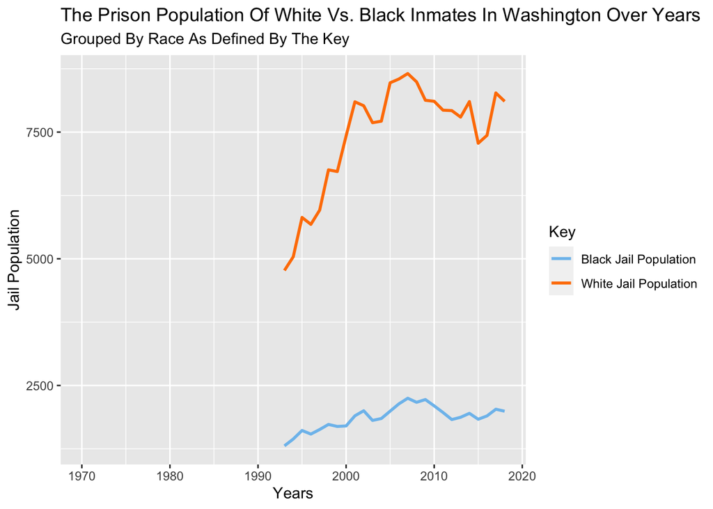

In my trends_over_time plot, my goal was to compare the increase or decrease in jail population for white inmates and black inmates in Washington. I chose Washington because I’m most familiar with the general demographic and so I would be able to interpret the information provided by the plot better. The result was an increase in white inmates from 1993 to around 2010. Then, the figures dip to approximately 7,300 before climbing again. These trends are similar to the trends for black inmates. However, I didn’t expect the increase to be so flat compared to the white inmates. While it made sense that the overall white jail population was greater than black jail populations each year, I didn’t realize that the white population was being incarcerated at a much steeper rate than the black population.

Perhaps this is due to the media focusing on this particular demographic and so it seems like black crime and black inmates make up the majority, when in reality, this isn’t the case.

Then, with this in mind, I wanted to further analyze and expand my findings to all the races jail population data collected by the dataset. So, I created another trends over time plot with just that.

```
## # A tibble: 51 × 2
##    state total_jail_pop
##    <chr>          <dbl>
##  1 AK                NA
##  2 AL             15184
##  3 AR              7978
##  4 AZ             12999
##  5 CA                NA
##  6 CO                NA
##  7 CT                NA
##  8 DC              2063
##  9 DE                NA
## 10 FL             54835
## # … with 41 more rows
```

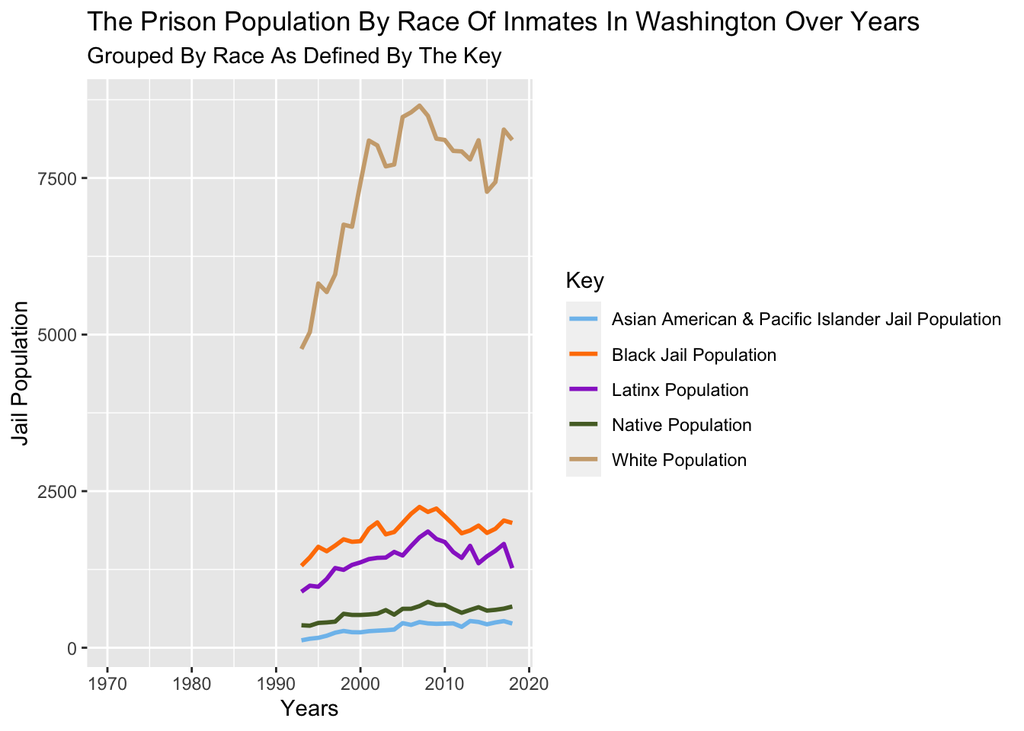

Here, I could see that the increase with the white population in jail is vastly different than the increase in population for all black , latinx, native, and asian american & pacific islanders.

## Variable Comparison Plot

```
## # A tibble: 51 × 2
##    state total_jail_pop
##    <chr>          <dbl>
##  1 AK                NA
##  2 AL             15184
##  3 AR              7978
##  4 AZ             12999
##  5 CA                NA
##  6 CO                NA
##  7 CT                NA
##  8 DC              2063
##  9 DE                NA
## 10 FL             54835
## # … with 41 more rows
```

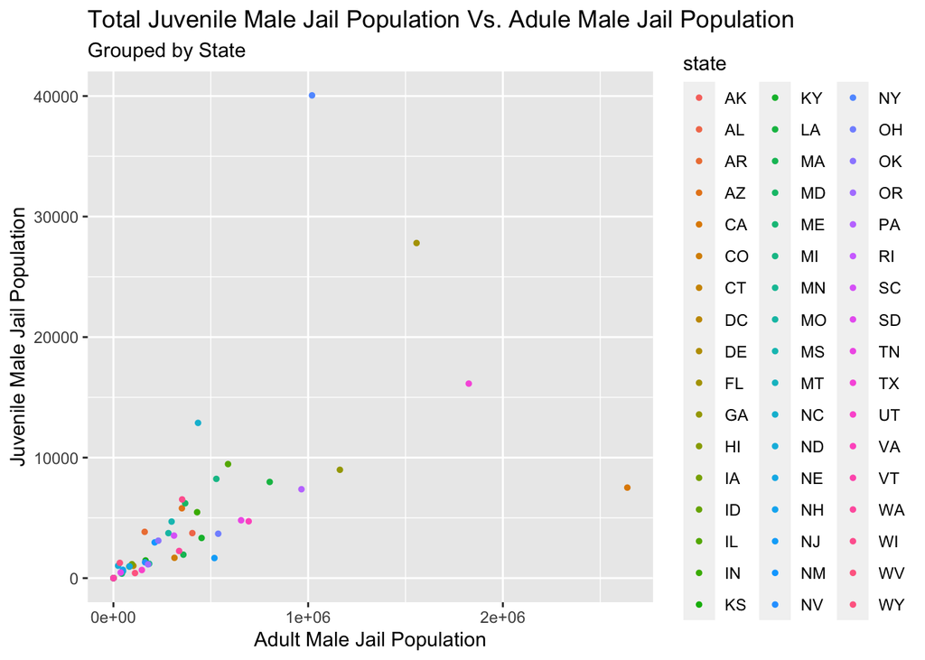

For my 2 variable comparison chart, I wanted to find if there was a correlation between the total jail population of juvenile males in each state compared to the total number of adult males in prions. Though I wanted to focus on race, there is no doubt that another big factor in these incarceration rates is the influence of a father-like figure in a child’s life. Especially for a young male, a father figure could heavily influence the future and outlook of the child.

In plotting the Juvenile Male Jail Population Vs. the Adult Male Jail Population, I found that there seems to be a positive correlation between the two variables for each of the states. This means that the more adult males there are in prison, the more juvenile males are in prison also. The only major outliers I could see is New York (NY) with a much larger juvenile male jail population than adult male jail population compared to other states and California (CA), where there is a much larger adult male jail population than juveniles. That said, it may be that these two are the largest states in the country and could carry a lot more people, and so the data may be a bit biased or skewed.